# The Brighton Secondary School System - A Strategic View

### 21.1.2 What the council actually tells parents to look at

This is not a hypothetical failure of communication. The council’s own *Secondary school admissions guide 2026–2027* opens with a section called **“Before you make your application”**, which lists what a family should consider. Under *Look at the school’s prospectus*, it says the prospectus will give an idea of the school’s:

> ethos and character · National Curriculum test results · public exam results

Two of those three are raw attainment. The section goes on to recommend reading Ofsted reports, visiting schools, checking admission numbers and catchment, thinking about travel, and using all four preferences — all sensible, and much of it genuinely useful.

**What the guide never mentions, anywhere, is that a school’s exam results largely describe the children who sit them.** There is no reference to Progress 8, to value added, to contextual measures, or to any figure that separates what a school achieves from who it admits. The performance signals the guide names are exactly the ones that correlate with intake affluence at 0.87.

**ImportantThe authority is not a neutral party in this**

Every mechanism in this report runs on what families believe they are choosing between. The council does not merely observe those beliefs; **it is the single largest source of guidance shaping them.** This document goes to every family in the city applying for a Year 7 place, at the moment they are deciding.

The guidance is not wrong in what it says. It is incomplete in a way that runs consistently in one direction. A parent following it exactly — visiting schools, reading prospectuses, comparing exam results, checking Ofsted — would arrive at the ordering this report shows families actually produce: one that tracks raw attainment closely and what schools contribute barely at all. The guide advises looking widely, including “schools outside your immediate area”, which amplifies rather than moderates the effect.

The result is an authority spending considerable effort on admission arrangements intended to even out school intakes, while its own advice to parents points at the measure that drives them apart. Those two activities work against each other, and only one of them is cheap to change.

**And the format already exists.** Later in the same guide, every school gets a table: number on roll, preferences received at each rank, places offered under each admission criterion, and the admission number. The council is evidently willing and able to publish a per-school table in this document. What that table contains is admissions arithmetic and nothing about what a school does for the children in it.

**Adding a column would do it** - an intake-adjusted measure beside the admission number, with a sentence saying that headline results substantially reflect the attainment of the children who join a school, and that a school with modest raw results may be adding a great deal. No new page, no new format, no new process. A column in a table the council already builds.

It is worth being clear that this is not an accusation of intent. The guide reads like a document assembled to be helpful and complete on process, by people whose job is admissions rather than performance measurement. But the omission is consequential, the authority is the one making it, and it is the cheapest correction available anywhere in this report.

# 22 What if other schools shrink too?

Every scenario so far treats Longhill as the only school whose size is in question. A falling cohort presses on all of them at once, and several have their own reasons to want to be smaller — Cardinal Newman most of all, at 360 by some distance the largest in the city.

This is testable with published data alone: admission numbers are public, and the model already redistributes displaced demand. The scenarios below use the adjudicator’s binding 2026/27 numbers, which matters, because the council’s proposed reductions at Blatchington Mill and Dorothy Stringer were overturned — 60 central places the council meant to remove stay in the system.

**ImportantRebuilt on the full model, and the earlier table withdrawn**

An earlier version of this section answered the question on the swept model, and its table was easy to misread and wrong in two ways. It reported Longhill’s **natural recruitment** — what it would draw with its own admission number removed — which on that model sat far above anything the school takes, so a row reading “Cardinal Newman 300” beside a figure in the two hundreds invited exactly the wrong reading. And that model let every family in the city choose a faith school while leaving Cardinal Newman short of its places, so cutting Cardinal Newman changed nothing at all.

Both problems are gone here. These runs use the full model as the simulator runs it: catchment terms and attractiveness fitted to what each catchment’s children ask for, with Cardinal Newman full; the council’s 2026/27 priorities; children refused at a full school re-offered by second preference; and the East Sussex schools as destinations. **Longhill keeps its admission number of 210, so every figure is the children it would take.**

```r
sr$pan_scenarios %>%
  mutate(longhill = round(longhill)) %>%
  select(scenario, entry_year, longhill) %>%
  pivot_wider(names_from = entry_year, values_from = longhill) %>%
  rename(Scenario = scenario) %>%
  tbl(caption = "Longhill's intake, at its admission number of 210, when other schools reduce theirs. Full model with the council's 2026/27 priorities; each school keeps the number the adjudicator determined unless the row says otherwise.")
```

Longhill's intake, at its admission number of 210, when other schools reduce theirs. Full model with the council's 2026/27 priorities; each school keeps the number the adjudicator determined unless the row says otherwise.

| Scenario | 2026 | 2030 | 2035 |
| --- | --- | --- | --- |
| As determined | 91 | 75 | 67 |
| Cardinal Newman 300 | 99 | 78 | 70 |
| Cardinal Newman 270 | 105 | 79 | 72 |
| King's 150 | 94 | 76 | 69 |
| Cardinal Newman 270, King's 150 | 110 | 80 | 73 |
| Dorothy Stringer 300 | 95 | 75 | 67 |
| Dorothy Stringer 270 | 101 | 75 | 67 |
| Stringer 300, Varndean 270, Blatchington Mill 300 | 107 | 75 | 68 |
| Brighton Aldridge 150 | 91 | 75 | 67 |
| Cardinal Newman 270, Stringer 270 | 117 | 79 | 72 |
| Cardinal Newman 270, Stringer 270, Brighton Aldridge 150 | 117 | 79 | 72 |

**Brighton Aldridge’s reduction does nothing for Longhill**: 0 in 2026. It does not fill, so a lower number only removes its own empty places.

**Longhill gets a minority of the children any reduction frees.** Of the places Cardinal Newman at 270 and King’s at 150 take out of the system in 2026, 16% end up at Longhill; the rest go to the schools families rank next, most of them nearer home.

```r
pm %>%
  filter(scenario %in% c("Cardinal Newman 270, King's 150", "Stringer 300, Varndean 270, Blatchington Mill 300")) %>%
  transmute(Scenario = scenario, School = short, `Change in intake, 2026` = sprintf("%+.0f", change)) %>%
  tbl(caption = "Where the children two of the reductions free actually go, 2026")
```

Where the children two of the reductions free actually go, 2026

| Scenario | School | Change in intake, 2026 |
| --- | --- | --- |
| Cardinal Newman 270, King's 150 | Brighton Aldridge | +25 |
| Cardinal Newman 270, King's 150 | Cardinal Newman | -90 |
| Cardinal Newman 270, King's 150 | Hove Park | +15 |
| Cardinal Newman 270, King's 150 | King's | -30 |
| Cardinal Newman 270, King's 150 | Longhill | +19 |
| Cardinal Newman 270, King's 150 | Patcham | +12 |
| Cardinal Newman 270, King's 150 | Portslade Aldridge | +50 |
| Stringer 300, Varndean 270, Blatchington Mill 300 | Blatchington Mill | -30 |
| Stringer 300, Varndean 270, Blatchington Mill 300 | Brighton Aldridge | +24 |
| Stringer 300, Varndean 270, Blatchington Mill 300 | Dorothy Stringer | -30 |
| Stringer 300, Varndean 270, Blatchington Mill 300 | Hove Park | +15 |
| Stringer 300, Varndean 270, Blatchington Mill 300 | Longhill | +16 |
| Stringer 300, Varndean 270, Blatchington Mill 300 | Patcham | +12 |
| Stringer 300, Varndean 270, Blatchington Mill 300 | Portslade Aldridge | +24 |
| Stringer 300, Varndean 270, Blatchington Mill 300 | Varndean | -30 |

For comparison with the withdrawn table: with its own admission number removed as well, Longhill would draw 91 children in 2026 on the full model with nothing else changed, against 91 at 210 — it is not short of places, it is short of families.

The academies and faith schools are modelled as responding to demand. The council cannot set their numbers; it can ask, and the table above is the evidence for asking. The strategic view weighs these reductions against the council’s other priorities, including the finances of the community schools, which Cardinal Newman and King’s taking fewer improves more than any other single change the council does not control.

# 23 How much does any of this depend on unknowns?

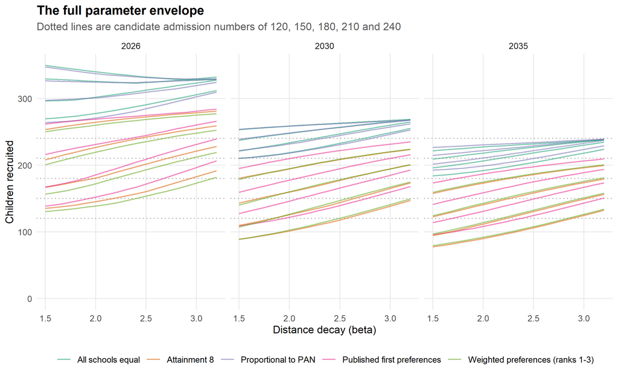

Longhill’s natural intake across every combination swept. Each line is one attractiveness specification at one catchment-effect strength.

```r
env$envelope %>%
  filter(site == "now") %>%
  ggplot(aes(beta, natural_intake, colour = w_label,
             group = interaction(w_label, gamma))) +
  geom_hline(yintercept = env$pans, linetype = "dotted", colour = "grey65") +
  geom_line(alpha = 0.55, linewidth = 0.6) +
  facet_wrap(~ entry_year, nrow = 1) +
  scale_colour_brewer(palette = "Dark2") +
  expand_limits(y = 0) +
  labs(title = "The full parameter envelope",
       subtitle = "Dotted lines are candidate admission numbers of 120, 150, 180, 210 and 240",
       x = "Distance decay (beta)", y = "Children recruited", colour = NULL) +
  theme(legend.position = "bottom")
```

```r
env$importance %>%
  filter(term != "Residuals") %>%
  mutate(term = recode(term,
    "w_spec" = "Which attractiveness specification",
    "factor(entry_year)" = "Which year",
    "factor(gamma)" = "Strength of catchment priority",
    "factor(beta)" = "Distance decay (beta)",
    "site_label" = "Site (Ovingdean or Elm Grove)")) %>%
  transmute(Input = term, `Share of variation (%)` = round(pct, 1)) %>%
  tbl(caption = "What the answer is actually sensitive to")
```

What the answer is actually sensitive to

| Input | Share of variation (%) |
| --- | --- |
| Which attractiveness specification | 45.5 |
| Which year | 21.0 |
| Site (Ovingdean or Elm Grove) | 13.7 |
| Distance decay (beta) | 7.2 |
| Strength of catchment priority | 4.8 |

**NoteWhat restricted data would and would not add**

The single most consequential unknown is **not** how sharply families discount distance. Distance decay accounts for 7.2% of the variation in the answer. **How attractive each school is, net of where it sits, accounts for 45.5%.**

**CautionThe centre of the envelope is probably not the best estimate**

This is the most important thing to know about every range quoted in this document.

At the current site in 2035, the sweep spans **78 to 239 children, with a median of 184.** The full model puts it at about **65** — at the floor of the range, not the middle.

The sweep is doing its job: it brackets the plausible answers, which is the point of sweeping rather than guessing. But a reader naturally treats the centre of a range as the best estimate, and there are two reasons to think that would be wrong here — in both cases towards the optimistic side.

The first is visible in the table above. The **attractiveness specification accounts for 45.5% of the variation** — far more than distance decay or catchment priority — and none of the four open specifications capture how strongly families avoid Longhill, because published data does not record avoidance. All four therefore err in the same direction rather than scattering either side of the truth, which is what a median assumes.

The second is the validation: the model over-predicts Longhill against actual offers, and does so consistently. A specification that is known to over-predict does not become unbiased when averaged with three others sharing the same blind spot.

**Read the lower part of every envelope in this document as the operative range, not the median.** Where a figure is quoted with a band around it, the weight of the evidence sits at its pessimistic end.

**Recommendation: replace this sweep with a measurement.** Sweeping is the right response to not knowing, and it is why the conclusions here are stated as ranges. But it is a second-best. The single input that would collapse the widest band in this document — how attractive each school is, net of where it stands — is recoverable from the council’s admissions records by a standard regression, and would turn 45.5% of the uncertainty into a fitted coefficient.

I would carry out that work with the council, share the code and the outputs, and publish nothing disclosive. What the authority would get in return is not a better version of this document: it is a model of its own school system that can be re-run against any proposal before it is consulted on, rather than argued about afterwards.

# 24 What this shows, and what it does not

**What holds without any modelling assumption at all**

- Longhill has the lowest potential accessibility to the city’s children of any secondary school in Brighton (Section 5), at 65 against a city average of 100 — and it has the fewest competing schools nearby, so that is a reach problem rather than a crowding one.
- The Elm Grove site is better placed at every distance decay tested. This is the one conclusion here that requires no view on attractiveness, admissions priority, or family behaviour.

**What the full model shows**

- Longhill takes about 91 children in 2026 and 75 in 2030 where it is, on an admission number of 210, and no configuration draws 150 after 2026. Cutting its number removes empty places and adds no children (Section 16.2).
- A move on its own does not help Longhill; a move with a catchment map drawn round the new site does, to about 103 in 2030, and it closes the gap between disadvantaged children’s journeys and everyone else’s while concentrating disadvantage in one school (Section 18.2).
- Cardinal Newman and King’s taking fewer adds children to Longhill that last; trimming the full central schools helps only while they are full; Brighton Aldridge taking fewer does nothing for it (Section 22).
- Returning Whitehawk to Longhill’s catchment adds children and lowers displacement, and its effect on how mixed intakes are is too small to call (Section 19).
- No option makes Longhill break even.

**What holds across the whole swept model**

**What this analysis cannot settle**

- How closely families would follow a redrawn catchment. Every redraw and relocation result assumes they follow a new map as closely as the one they have, and the answer turns on it: with the catchment terms halved, a move on its own would help (53 children at Elm Grove against 45 at Ovingdean in 2030).
- How sharply distance deters families, which the full model sets rather than fits because a catchment-level table cannot identify it.
- What happens to children academically. This models where they would go, not what happens when they get there — for which see school_attainment_tool, which finds absence a far more powerful lever than any redistribution of intake.
- Anything below catchment level about who goes where.

**Standing limits**

- Travel times are routed throughout, including the expansion area and the Elm Grove site. The `r5r` network was rebuilt over a merged East and West Sussex extract; no journey time to a city school is inferred from straight-line distance. Journeys to the East Sussex schools use straight-line distance, because the bus network has no direct eastern route to Lewes.
- The swept model over-predicts Longhill by 89 children against published offers; the full model largely closes that gap.
- Ten destinations means anything about *why* a school is attractive rests on ten observations.
- The academies and faith schools are modelled as responding to demand, not as setting their own numbers.

# 25 What the council’s own data would settle

This document is built entirely from published sources, and that constraint has been productive: it forces every claim to be checkable by anyone. But it has been binding at specific, identifiable points, and it is worth naming them — partly so readers know where the analysis is weakest, and partly because the data that would fix them already exists.

The council holds individual preference and offer records: for each applicant, the schools named in order, the criterion under which a place was allocated, and the home postcode. Nothing below needs anything the admissions process does not already generate.

**Where the swept model is demonstrably wrong, and would stop being.** The validation shows the swept model over-predicting Longhill by a wide margin once routed journey times are used; the full model, fitted to the council’s catchment preference table, closes most of that gap, and individual records would close the rest. The reason is structural: the model can see how reachable a school is, but nothing in published data records how strongly families *avoid* one. Preference records supply exactly that, as a school-level term fitted rather than assumed. Until then every relocation figure here is an upper bound, and the report says so repeatedly because it is the single largest source of error in it.

**Whether catchment priority is worth anything.** This document has to assume a value for how much being in catchment shifts a family’s choice, and sweeps it across a wide band because the assumption cannot be tested openly. Records settle it directly, by school: compare offer rates for in-catchment and out-of-catchment applicants who named the same school. The expected answer at Longhill is **close to nothing**, since an undersubscribed school turns almost nobody away whether they live in catchment or out. If that is borne out, redrawing Longhill’s catchment cannot work through priority at all — only through what families are willing to name. That is a conclusion with direct policy consequences and it is invisible in published data.

**Choice or chance.** The consultation argument that dual catchments confer “choice” can only be tested against individual preferences. The relevant number is the share of in-catchment applicants who named a school first and were refused it. The expectation is that it runs high at the oversubscribed school in a pair and near zero at the others — in which case the “choice” is real at some schools and a lottery at others. Published aggregates cannot distinguish those two situations at all.

**How much deprivation the catchment averages conceal.** Section 18.3.2 shows the pairing masking a substantial social boundary in Hove, but understating it: about 18 percentage points here, and address-level data would very likely show it wider. Postcode-level home addresses would remove the approximation entirely, and with it the caveat that currently sits on the most policy-relevant finding in this document.

**Who leaves, and why.** Roughly a fifth of the city’s children do not enter its state secondary schools. Published data cannot say whether they go independent, to a faith school, or out of the authority, nor where they live. Records can, and the east-of-the-city pattern that emerges is central to any judgement about Longhill’s future.

Five sections of this report exist only to mark where published data runs out: Section 6, Section 9, Section 11, Section 12 and Section 19. Each says what cannot be established here and what the records would establish. They are the shape of the offer.

None of this requires new collection, a survey, or a change of practice. It requires access to records the admissions process produces as a by-product, under the arrangements that already govern research use of pupil data.

## 25.1 And one thing that needs no arrangements at all

There is a smaller ask that could be met immediately, and it is worth separating from the rest because it involves no personal data and no agreement of any kind.

When the adjudicator determined the 2026/27 objections, the council produced an evidence bundle: catchment boundaries, pupil forecasts, deprivation indices, and **preference and allocation counts by catchment area** — which school each catchment’s children named, in what order, and where they were offered places. As set out in Section 2.1, that material reached me as an objector to the case but was never published.

It is aggregated to catchment level throughout. Nothing in it identifies anyone. And it answers several of the questions this report has had to leave open — a catchment-level origin–destination matrix is the very thing Section 23 identifies as the largest single source of uncertainty here. *It is item two at Section 25.3.*

**Publishing that bundle would cost the council nothing and would let every party to this debate argue from the same evidence.** At present the authority, the objectors and the adjudicator have seen it; residents, governors and anyone reading this document have not. For a decision that will shape the city’s schools for fifteen years, that asymmetry is hard to justify — and unlike the pupil-record request above, removing it requires no one’s permission but the council’s own.

## 25.2 Why this is worth doing now rather than later

The case is not that the analysis would be interesting. It is that the city is about to make a series of decisions that will bind for fifteen to twenty years, and is making them one at a time.

Consider what is in front of the council across the next few rounds: Longhill’s admission number and possibly its site; Dorothy Stringer’s admission number, already once refused by the adjudicator; the free school meals criterion, whose reach is about to be cut by nearly half by a change in national eligibility rules; the catchment map, redrawn in 2024 and not yet settled; and the arrival of four wards and a further secondary school in 2028. Each of these is currently a separate decision with a separate evidence base and a separate consultation.

**They are not separate.** Every result in this document says so. Reducing one school’s admission number pushes demand onto its neighbours and the effect concentrates, unevenly, on the school least able to absorb it. Redrawing a catchment changes who is in it, and therefore the social composition of two schools, not one. Relocating a school severs it from part of its hinterland while gaining another part. A model of the whole system is the only way to see any of that before it happens rather than afterwards.

The demographic reality makes this urgent rather than optional. The cohort is falling, the fall is not evenly distributed across the city, and surplus capacity has to land somewhere. A city that decides where it lands, deliberately and once, will get a better answer than one that discovers where it landed after five years of separate decisions each of which seemed reasonable in isolation.

That is what this work is for. It is not an argument for any particular outcome for Longhill, or for any school — the results here point in different directions depending on what the city decides it values, and the report says so wherever that happens. It is an argument for having the conversation with the whole picture in view, and for doing so while there is still time for the answer to matter.

The offer stands: the model, the code, and the analysis are open, and the parts that need records will be done properly and shared if the records are made available.

## 25.3 A specific list of tables the council could simply publish

Everything above is framed as access to records, which needs arrangements. Most of what this analysis lacks does not. It is a short list of **aggregate tables** — nothing at pupil level, nothing disclosive, most of them a single query against systems the admissions process already runs.

They are set out below with the question each would answer, because a data request without a purpose is easy to decline and easy to deprioritise.

```r
tibble::tribble(
  ~Table, ~Granularity, ~`What it would settle`,
  "Offers by school × IDACI band",
  "School × decile band, one row per year",
  "Which schools admit more or fewer disadvantaged children than their size implies. Cannot currently be computed from any published source, and it is the single most useful table on this list.",

  "Preferences and offers by catchment area",
  "Catchment × school × preference rank",
  "Whether catchment priority does anything at each school, and where each school's applicants actually live. Already produced for the Adjudicator in 2025 but never published.",

  "First preferences by small area, before and after 2024",
  "LSOA or ward × school × year",
  "Whether being placed in a catchment changes what families name — the assumption the case for redrawing rests on, and which nothing published can test.",

  "Children offered a place outside the authority",
  "Home catchment × destination authority",
  "Why roughly a fifth of the city's children never enter its state secondaries, which is the largest single quantity in this analysis.",

  "Free school meals eligibility by catchment",
  "Catchment × year",
  "How the FSM criterion's reach changes as national eligibility narrows, and which catchments lose most.",

  "Sibling links by school",
  "School × year, counts only",
  "How much of each school's intake is already determined before any policy change, which bounds what any reform can move.",

  "Appeals and their outcomes",
  "School × ground × outcome × year",
  "Where the arrangement is producing outcomes families successfully contest, which is a direct measure of where it is failing.",

  "Children allocated a school they did not name, by preferences used",
  "Number of preferences expressed × home catchment × year",
  "Whether these families failed to engage or engaged and aimed badly. The distinction decides whether the remedy is outreach or better guidance about which schools are realistically obtainable, and nothing published distinguishes them.",

  "Distance from home to allocated school, where no preference was met",
  "Banded distance × year, counts only",
  "Whether the nearest-school-with-a-place rule the council described to the Adjudicator is borne out in practice. It is the authority's own stated policy and at present no one outside it can check whether the allocations match."
) %>%
  tbl(caption = "Aggregate tables the council could publish without disclosure risk, and the question each would answer")
```

Aggregate tables the council could publish without disclosure risk, and the question each would answer

[output not shown]

None of these is a research dataset. They are the by-products of running an admissions round, aggregated to a level at which no individual is identifiable. Several already exist as internal management information.

The last two are worth a word, because they are the only items on this list that would let an outside reader check something the authority has **stated**. The council has told the Adjudicator how unmatched children are placed, and it tells families in its guide to use all four preferences. Neither claim can currently be verified from anything published. Publishing two small count tables would make both checkable, and an authority confident in its own process loses nothing by allowing that.

**ImportantPublishing this would help the council more than it helps me**

It is worth being direct about the culture this sits in. Almost every useful figure in this report came out either because the Schools Adjudicator required it, or because someone asked under the Freedom of Information Act. That is a poor way to run an evidence base, and the cost falls in three places.

**On the council.** An authority that releases data only under compulsion ends up arguing its case with whatever it has released, which is rarely the strongest material it holds. The council’s own leakage assumption for Longhill is a good example: it is broadly right, and it looks arbitrary because the evidence for it was never published alongside it. Publishing would have made the same decision easier to defend.

**On schools.** A head teacher cannot see how their intake compares with the city, how their catchment’s demography is moving, or how many of their applicants named them first. Those are the basic facts of running a school in a falling market, and at present each school sees only its own corner. Several of the objections in the 2026/27 case read as schools reasoning from partial information — which is not a criticism of them.

**On everyone else.** Consultations attract the arguments of whoever can assemble numbers. Where the evidence is closed, that means whoever is most determined rather than most representative, and the authority then has to adjudicate between claims it cannot easily check.

The alternative is not onerous. **A single annual publication — the tables above, released alongside the allocation factsheets that already appear each March — would let every party to these debates argue from the same evidence.** It would cost a day of officer time a year. It would remove most of the caveats in this document, and it would make the next reorganisation a conversation about what the city wants rather than about whose numbers to believe.

I would rather this analysis were made redundant by better published data than be the only place some of these questions get asked.

# 26 Testable predictions

If any is wrong, the data to show it exists. We would welcome the correction.

# 27 Sources

| Input | Source |
| --- | --- |
| Travel times | `r5r` routing over OpenStreetMap and Brighton & Hove GTFS, May 2024 |
| Admissions, PAN, preferences | Brighton & Hove City Council published allocation factsheets, 2013–2026 |
| School characteristics | DfE [Get Information About Schools](https://get-information-schools.service.gov.uk/) |
| Attainment, Ofsted, finance | DfE performance tables, via school_attainment_tool |
| Population | ONS small area population estimates, mid-2022 |
| Offers outside the city, by catchment | Office of the Schools Adjudicator, determination of 20 October 2025, Table 11 |
| Offers by catchment and destination school, 2024 | Brighton & Hove City Council, FOI response [published on WhatDoTheyKnow](https://www.whatdotheyknow.com/request/schools_admissions_breakdowns_fo) |
| Year 7 offers by priority, free school meal and priority-6 places | Brighton & Hove City Council, Year 7 allocation factsheets, September 2025 and September 2026 |
| Disadvantaged pupils by school | DfE performance tables, PTFSM6CLA1A |
| Catchment-level preferences and allocations | Brighton & Hove City Council, evidence to the Schools Adjudicator, item 8.1 (received as a party to the case) |
| Scenario runs on the full model | The policy simulator, bh-school-system, built from this bundle and the sources above |
| Boundaries | ONS Open Geography Portal; council catchment map |
| Reorganisation | [MHCLG decision letters](https://www.gov.uk/government/publications/local-government-reorganisation-decision-letters-to-council-leaders), 16 July 2026 |

```r
source("public/run_public.R")
quarto::quarto_render("public/bh_school_sim_open.qmd")
```